# Introducción a Business Analytics

Tidydata

Eduard Fernando Martínez González

https://eduard-martinez.github.io

edfemagonza@gmail.com

[@emartigo](https://twitter.com/emartigo)

eduard-martinez

eduard-martinez

## **[1.] Introducción a Tidyverse**

[figure not shown]

Source: Allison Horst

`tidyverse` es un conjunto de paquetes de R diseñados para la ciencia de datos. Todos los paquetes comparten una filosofía de diseño subyacente, gramática y estructuras de datos, lo que facilita el flujo de trabajo en el análisis de datos. El término y el conjunto de paquetes fueron desarrollados principalmente por Hadley Wickham, uno de los contribuyentes más prominentes a la comunidad de R.

Los paquetes en `tidyverse` se dividen en dos categorías principales:

1. **Core tidyverse:** Estos son paquetes que la mayoría de los usuarios de `tidyverse` utilizarán en casi todos los análisis. Incluyen:
   - `ggplot2` para la creación de gráficos.
   - `dplyr` para la manipulación de datos.
   - `tidyr` para convertir datos a formato “tidy”.
   - `readr` para la lectura de datos tabulares.
   - `purrr` para programación funcional.
   - `tibble` para el manejo de tablas de datos en memoria.
   - `stringr` para la manipulación de cadenas de texto.
   - `forcats` para el manejo de factores.
   - `lubridate` para el manejo de fechas.
2. **Paquetes de modelado:** Centrados alrededor del ecosistema de `tidymodels`, estos paquetes son para modelado estadístico y aprendizaje automático, y se integran bien con el resto del `tidyverse`.

### **1.1. Instalar y cargar el tidyverse en su entorno de R**

```r
library("tidyverse")
```

```r
── Attaching core tidyverse packages ───────────────────────── tidyverse 2.0.0 ──
✔ dplyr     1.1.4     ✔ readr     2.1.5
✔ forcats   1.0.0     ✔ stringr   1.5.1
✔ ggplot2   3.5.1     ✔ tibble    3.2.1
✔ lubridate 1.9.4     ✔ tidyr     1.3.1
✔ purrr     1.0.2
── Conflicts ─────────────────────────────────────────── tidyverse_conflicts() ──
✖ dplyr::filter() masks stats::filter()
✖ dplyr::lag()    masks stats::lag()
```

Para ver los conflictos entre nombres de funciones en `tidyverse` con nombre de funciones en otras librerías, puede escribir sobre la consola `tidyverse_conflicts()`

### **1.2. Cheat sheet**

[figure not shown]

Las cheat sheets son resúmenes visuales que condensan información clave sobre cada uno de los paquetes. Ayudando a recordar funciones esenciales, sintaxis y mejores prácticas de codificación de manera rápida y sencilla. Algunas están incluso en Español.

Puede encontrar una hoja de trucos para cada librería [aquí](https://www.rstudio.com/resources/cheatsheets/).

## **[2.] Adicionar variables a un conjunto de datos**

Puedes adicionar variables a un `dataframe`/`tibble` usando *data$var* de la librería `base` de R o con la función *mutate()* de la librería `dplyr`.

### **2.1. Conjuntos de datos disponibles en la memoria de R**

```r
data(package="datasets")
```

```r
Data sets in package ‘datasets’:

iris                            Edgar Anderson´s Iris Data
iris3                           Edgar Anderson´s Iris Data
islands                         Areas of the World´s Major Landmasses
ldeaths (UKLungDeaths)          Monthly Deaths from Lung Diseases in the UK
lh                              Luteinizing Hormone in Blood Samples
longley                         Longley´s Economic Regression Data
lynx                            Annual Canadian Lynx trappings 1821-1934
mdeaths (UKLungDeaths)          Monthly Deaths from Lung Diseases in the UK
morley                          Michelson Speed of Light Data
mtcars                          Motor Trend Car Road Tests
uspop                           Populations Recorded by the US Census
volcano                         Topographic Information on Auckland´s Maunga Whau Volcano
women                           Average Heights and Weights for American Women
```

Se muestran solo algunos de los conjuntos de datos disponibles en la librería `datasets`.

### **2.2 Función `$`**

Crear un objeto con la base de datos `women`:

```r
df = tibble(women) # Obtener dataset
df
```

```
## # A tibble: 15 × 2
##    height weight
##     <dbl>  <dbl>
##  1     58    115
##  2     59    117
##  3     60    120
##  4     61    123
##  5     62    126
##  6     63    129
##  7     64    132
##  8     65    135
##  9     66    139
## 10     67    142
## 11     68    146
## 12     69    150
## 13     70    154
## 14     71    159
## 15     72    164
```

Crear una variable con la estatura en centímetros (1 pulgada = 2.54 centímetros):

```r
df$height_cm = df$height*2.54 # agregar nueva variable
df
```

```
## # A tibble: 15 × 3
##    height weight height_cm
##     <dbl>  <dbl>     <dbl>
##  1     58    115      147.
##  2     59    117      150.
##  3     60    120      152.
##  4     61    123      155.
##  5     62    126      157.
##  6     63    129      160.
##  7     64    132      163.
##  8     65    135      165.
##  9     66    139      168.
## 10     67    142      170.
## 11     68    146      173.
## 12     69    150      175.
## 13     70    154      178.
## 14     71    159      180.
## 15     72    164      183.
```

### **2.3 mutate()**

Generar una variable con la relación weight/height_cm:

```r
df = mutate(.data = df , weight_hcm = weight/height_cm)
head(x=df, n=5)
```

```
## # A tibble: 5 × 4
##   height weight height_cm weight_hcm
##    <dbl>  <dbl>     <dbl>      <dbl>
## 1     58    115      147.      0.781
## 2     59    117      150.      0.781
## 3     60    120      152.      0.787
## 4     61    123      155.      0.794
## 5     62    126      157.      0.800
```

### **2.4 Generar variables usando condicionales:**

| Operador lógico | Descripción |
| --- | --- |
| < , > | Menor y mayor que… |
| <= , >= | Menor o igual y mayor igual que… |
| `==` | Igual a… |
| `!=` | Diferente de… |
| & | y |
| `\|` | o |
| `!` | Negación |

```r
# data$var
df$height_180 = ifelse(test=df$height_cm>180 , yes=1 , no=0)

#mutate
df = mutate(.data=df , sobrepeso = ifelse(test=weight_hcm>=0.85 , yes=1 , no=0))

head(x=df, n=5)
```

```
## # A tibble: 5 × 6
##   height weight height_cm weight_hcm height_180 sobrepeso
##    <dbl>  <dbl>     <dbl>      <dbl>      <dbl>     <dbl>
## 1     58    115      147.      0.781          0         0
## 2     59    117      150.      0.781          0         0
## 3     60    120      152.      0.787          0         0
## 4     61    123      155.      0.794          0         0
## 5     62    126      157.      0.800          0         0
```

Generar una variable con categorías para la relación weight/height_cm.

```r
df = mutate(df , category = case_when(weight_hcm>=0.85 ~ "pesado" ,
                                      weight_hcm>=0.8 & weight_hcm<0.85 ~ "promedio" ,
                                      weight_hcm<0.8 ~ "liviano"))
head(x=df, n=5)
```

```
## # A tibble: 5 × 7
##   height weight height_cm weight_hcm height_180 sobrepeso category
##    <dbl>  <dbl>     <dbl>      <dbl>      <dbl>     <dbl> <chr>
## 1     58    115      147.      0.781          0         0 liviano
## 2     59    117      150.      0.781          0         0 liviano
## 3     60    120      152.      0.787          0         0 liviano
## 4     61    123      155.      0.794          0         0 liviano
## 5     62    126      157.      0.800          0         0 promedio
```

### **2.5 Aplicar funciones a variables**

Convertir todas las variables en caracteres:

```r
df = mutate_all(.tbl=df , .funs = as.character)
str(df)
```

```
## tibble [15 × 7] (S3: tbl_df/tbl/data.frame)
##  $ height    : chr [1:15] "58" "59" "60" "61" ...
##  $ weight    : chr [1:15] "115" "117" "120" "123" ...
##  $ height_cm : chr [1:15] "147.32" "149.86" "152.4" "154.94" ...
##  $ weight_hcm: chr [1:15] "0.780613630192778" "0.780728680101428" "0.78740157480315" "0.793855686072028" ...
##  $ height_180: chr [1:15] "0" "0" "0" "0" ...
##  $ sobrepeso : chr [1:15] "0" "0" "0" "0" ...
##  $ category  : chr [1:15] "liviano" "liviano" "liviano" "liviano" ...
```

Convertir solo algunas variables a numéricas:

```r
df = mutate_at(.tbl=df , .vars = c("height","weight","height_cm","weight_hcm"),.funs = as.numeric)
glimpse(df)
```

```
## Rows: 15
## Columns: 7
## $ height     <dbl> 58, 59, 60, 61, 62, 63, 64, 65, 66, 67, 68, 69, 70, 71, 72
## $ weight     <dbl> 115, 117, 120, 123, 126, 129, 132, 135, 139, 142, 146, 150,…
## $ height_cm  <dbl> 147.32, 149.86, 152.40, 154.94, 157.48, 160.02, 162.56, 165…
## $ weight_hcm <dbl> 0.7806136, 0.7807287, 0.7874016, 0.7938557, 0.8001016, 0.80…
## $ height_180 <chr> "0", "0", "0", "0", "0", "0", "0", "0", "0", "0", "0", "0",…
## $ sobrepeso  <chr> "0", "0", "0", "0", "0", "0", "0", "0", "0", "0", "0", "1",…
## $ category   <chr> "liviano", "liviano", "liviano", "liviano", "promedio", "pr…
```

Convertir a numéricas solo las variables que son caracteres:

```r
df2 = mutate_if(.tbl=df , .predicate = is.character,.funs = as.numeric)
glimpse(df2)
```

```
## Rows: 15
## Columns: 7
## $ height     <dbl> 58, 59, 60, 61, 62, 63, 64, 65, 66, 67, 68, 69, 70, 71, 72
## $ weight     <dbl> 115, 117, 120, 123, 126, 129, 132, 135, 139, 142, 146, 150,…
## $ height_cm  <dbl> 147.32, 149.86, 152.40, 154.94, 157.48, 160.02, 162.56, 165…
## $ weight_hcm <dbl> 0.7806136, 0.7807287, 0.7874016, 0.7938557, 0.8001016, 0.80…
## $ height_180 <dbl> 0, 0, 0, 0, 0, 0, 0, 0, 0, 0, 0, 0, 0, 1, 1
## $ sobrepeso  <dbl> 0, 0, 0, 0, 0, 0, 0, 0, 0, 0, 0, 1, 1, 1, 1
## $ category   <dbl> NA, NA, NA, NA, NA, NA, NA, NA, NA, NA, NA, NA, NA, NA, NA
```

### **2.6 Ordenar un objeto por los valores de una variable:**

Ordenar un dataframe: alfabético ascendente

```r
df = arrange(.data=df , category)
head(df)
```

```
## # A tibble: 6 × 7
##   height weight height_cm weight_hcm height_180 sobrepeso category
##    <dbl>  <dbl>     <dbl>      <dbl> <chr>      <chr>     <chr>
## 1     58    115      147.      0.781 0          0         liviano
## 2     59    117      150.      0.781 0          0         liviano
## 3     60    120      152.      0.787 0          0         liviano
## 4     61    123      155.      0.794 0          0         liviano
## 5     69    150      175.      0.856 0          1         pesado
## 6     70    154      178.      0.866 0          1         pesado
```

Ordenar un dataframe: alfabético descendente

```r
df = arrange(.data=df , desc(category))
head(df)
```

```
## # A tibble: 6 × 7
##   height weight height_cm weight_hcm height_180 sobrepeso category
##    <dbl>  <dbl>     <dbl>      <dbl> <chr>      <chr>     <chr>
## 1     62    126      157.      0.800 0          0         promedio
## 2     63    129      160.      0.806 0          0         promedio
## 3     64    132      163.      0.812 0          0         promedio
## 4     65    135      165.      0.818 0          0         promedio
## 5     66    139      168.      0.829 0          0         promedio
## 6     67    142      170.      0.834 0          0         promedio
```

Ordenar un dataframe: numérico ascendente

```r
df = arrange(.data=df , height_cm)
head(df)
```

```
## # A tibble: 6 × 7
##   height weight height_cm weight_hcm height_180 sobrepeso category
##    <dbl>  <dbl>     <dbl>      <dbl> <chr>      <chr>     <chr>
## 1     58    115      147.      0.781 0          0         liviano
## 2     59    117      150.      0.781 0          0         liviano
## 3     60    120      152.      0.787 0          0         liviano
## 4     61    123      155.      0.794 0          0         liviano
## 5     62    126      157.      0.800 0          0         promedio
## 6     63    129      160.      0.806 0          0         promedio
```

Ordenar un dataframe: numérico descendente

```r
df = arrange(.data=df , desc(height_cm))
head(df)
```

```
## # A tibble: 6 × 7
##   height weight height_cm weight_hcm height_180 sobrepeso category
##    <dbl>  <dbl>     <dbl>      <dbl> <chr>      <chr>     <chr>
## 1     72    164      183.      0.897 1          1         pesado
## 2     71    159      180.      0.882 1          1         pesado
## 3     70    154      178.      0.866 0          1         pesado
## 4     69    150      175.      0.856 0          1         pesado
## 5     68    146      173.      0.845 0          0         promedio
## 6     67    142      170.      0.834 0          0         promedio
```

## **[3.] Remover filas y/o columnas**

### **3.1 Seleccionar variables**

`iris` es un conjunto de datos de la librería `datasets`, que contiene las medidas en centímetros de la longitud y ancho del sépalo y largo y ancho del pétalo, respectivamente, para 50 flores de cada una de las 3 especies de iris:

```r
db =  mutate(.data = iris, Species=as.character(Species))
db[1:3,]
```

```
##   Sepal.Length Sepal.Width Petal.Length Petal.Width Species
## 1          5.1         3.5          1.4         0.2  setosa
## 2          4.9         3.0          1.4         0.2  setosa
## 3          4.7         3.2          1.3         0.2  setosa
```

La función `select()` permite seleccionar columnas de un dataframe o un tibble, usando el nombre o la posición de la variable en el conjunto de datos:

```r
select(.data = db[1:3,], c(1,3,5))
```

```
##   Sepal.Length Petal.Length Species
## 1          5.1          1.4  setosa
## 2          4.9          1.4  setosa
## 3          4.7          1.3  setosa
```

```r
select(.data = db[1:3,], Petal.Length , Petal.Width , Species)
```

```
##   Petal.Length Petal.Width Species
## 1          1.4         0.2  setosa
## 2          1.4         0.2  setosa
## 3          1.3         0.2  setosa
```

#### **3.1.1 Seleccionar variables usando partes del nombre**

Nombres de variable que empizan con (*Sepal*)

```r
select(.data = db[1:3,], starts_with("Sepal"))
```

```
##   Sepal.Length Sepal.Width
## 1          5.1         3.5
## 2          4.9         3.0
## 3          4.7         3.2
```

Nombres de variable que contengan la palabra (*Width*)

```r
select(.data = db[1:3,], contains("Width"))
```

```
##   Sepal.Width Petal.Width
## 1         3.5         0.2
## 2         3.0         0.2
## 3         3.2         0.2
```

#### **3.1.2 Seleccionar variables usando el tipo**

Variables de tipo carácter:

```r
select_if(.tbl = db[1:3,], is.character)
```

```
##   Species
## 1  setosa
## 2  setosa
## 3  setosa
```

Variables de tipo numérico:

```r
select_if(.tbl = db[1:3,], is.numeric)
```

```
##   Sepal.Length Sepal.Width Petal.Length Petal.Width
## 1          5.1         3.5          1.4         0.2
## 2          4.9         3.0          1.4         0.2
## 3          4.7         3.2          1.3         0.2
```

#### **3.1.3 Seleccionar variables usando un vector**

Vector de caracteres

```r
vars = c("Species","Sepal.Length","Petal.Width")
select(.data = db[1:3,], all_of(vars))
```

```
##   Species Sepal.Length Petal.Width
## 1  setosa          5.1         0.2
## 2  setosa          4.9         0.2
## 3  setosa          4.7         0.2
```

Vector numérico

```r
nums = c(5,2,3)
select(.data = db[1:3,], all_of(nums))
```

```
##   Species Sepal.Width Petal.Length
## 1  setosa         3.5          1.4
## 2  setosa         3.0          1.4
## 3  setosa         3.2          1.3
```

#### **3.1.4 Deseleccionar variables**

```r
select(.data = db[1:3,], -Species)
```

```
##   Sepal.Length Sepal.Width Petal.Length Petal.Width
## 1          5.1         3.5          1.4         0.2
## 2          4.9         3.0          1.4         0.2
## 3          4.7         3.2          1.3         0.2
```

### **3.2 Remover filas/observaciones**

En esta parte de la clase se empleará la base de datos [`starwars`](https://dplyr.tidyverse.org/reference/starwars.html) de la librería [`dplyr`](https://dplyr.tidyverse.org/).

```r
df = tibble(starwars)
df
```

```
## # A tibble: 87 × 14
##    name     height  mass hair_color skin_color eye_color birth_year sex   gender
##    <chr>     <int> <dbl> <chr>      <chr>      <chr>          <dbl> <chr> <chr>
##  1 Luke Sk…    172    77 blond      fair       blue            19   male  mascu…
##  2 C-3PO       167    75 <NA>       gold       yellow         112   none  mascu…
##  3 R2-D2        96    32 <NA>       white, bl… red             33   none  mascu…
##  4 Darth V…    202   136 none       white      yellow          41.9 male  mascu…
##  5 Leia Or…    150    49 brown      light      brown           19   fema… femin…
##  6 Owen La…    178   120 brown, gr… light      blue            52   male  mascu…
##  7 Beru Wh…    165    75 brown      light      blue            47   fema… femin…
##  8 R5-D4        97    32 <NA>       white, red red             NA   none  mascu…
##  9 Biggs D…    183    84 black      light      brown           24   male  mascu…
## 10 Obi-Wan…    182    77 auburn, w… fair       blue-gray       57   male  mascu…
## # ℹ 77 more rows
## # ℹ 5 more variables: homeworld <chr>, species <chr>, films <list>,
## #   vehicles <list>, starships <list>
```

#### **3.2.1 Remover filas usando condicionales**

La función `subset()` pertenece a una de las librerías base de `R` y permite seleccionar todas las filas/observaciones de un conjunto de datos que cumplen una o más condiciones lógicas:

```r
subset(x = df, height > 180)  # height mayor a 180
```

```
## # A tibble: 39 × 14
##    name     height  mass hair_color skin_color eye_color birth_year sex   gender
##    <chr>     <int> <dbl> <chr>      <chr>      <chr>          <dbl> <chr> <chr>
##  1 Darth V…    202 136   none       white      yellow          41.9 male  mascu…
##  2 Biggs D…    183  84   black      light      brown           24   male  mascu…
##  3 Obi-Wan…    182  77   auburn, w… fair       blue-gray       57   male  mascu…
##  4 Anakin …    188  84   blond      fair       blue            41.9 male  mascu…
##  5 Chewbac…    228 112   brown      unknown    blue           200   male  mascu…
##  6 Boba Fe…    183  78.2 black      fair       brown           31.5 male  mascu…
##  7 IG-88       200 140   none       metal      red             15   none  mascu…
##  8 Bossk       190 113   none       green      red             53   male  mascu…
##  9 Qui-Gon…    193  89   brown      fair       blue            92   male  mascu…
## 10 Nute Gu…    191  90   none       mottled g… red             NA   male  mascu…
## # ℹ 29 more rows
## # ℹ 5 more variables: homeworld <chr>, species <chr>, films <list>,
## #   vehicles <list>, starships <list>
```

La función `filter()` de la librería `dplyr` :

```r
filter(.data = df, mass > 100) # Más de 100 libras
```

```
## # A tibble: 10 × 14
##    name     height  mass hair_color skin_color eye_color birth_year sex   gender
##    <chr>     <int> <dbl> <chr>      <chr>      <chr>          <dbl> <chr> <chr>
##  1 Darth V…    202   136 none       white      yellow          41.9 male  mascu…
##  2 Owen La…    178   120 brown, gr… light      blue            52   male  mascu…
##  3 Chewbac…    228   112 brown      unknown    blue           200   male  mascu…
##  4 Jabba D…    175  1358 <NA>       green-tan… orange         600   herm… mascu…
##  5 Jek Ton…    180   110 brown      fair       blue            NA   <NA>  <NA>
##  6 IG-88       200   140 none       metal      red             15   none  mascu…
##  7 Bossk       190   113 none       green      red             53   male  mascu…
##  8 Dexter …    198   102 none       brown      yellow          NA   male  mascu…
##  9 Grievous    216   159 none       brown, wh… green, y…       NA   male  mascu…
## 10 Tarfful     234   136 brown      brown      blue            NA   male  mascu…
## # ℹ 5 more variables: homeworld <chr>, species <chr>, films <list>,
## #   vehicles <list>, starships <list>
```

El nombre de la función `filter()` presenta coflictos con el nombre de la función `filter()` de la librería `stats` (base).

```r
tidyverse_conflicts() # ver conflictos con los nombres de las funciones de tidyverse
```

```r
── Conflicts ───────────────────────────────────────────────────────────────────────────────── tidyverse_conflicts() ──
x dplyr::filter() masks stats::filter()
x dplyr::lag()    masks stats::lag()
```

Una forma de solucionar este conflicto es usar `::` para llamar la función de librería `dplyr::filter()` o creando un objeto con la función a preferir:

```r
filter = dplyr::filter # Tenga en cuenta que no se usa paréntesis.
filter(.data = df, mass > 100)  # Más de 100 libras
```

```
## # A tibble: 10 × 14
##    name     height  mass hair_color skin_color eye_color birth_year sex   gender
##    <chr>     <int> <dbl> <chr>      <chr>      <chr>          <dbl> <chr> <chr>
##  1 Darth V…    202   136 none       white      yellow          41.9 male  mascu…
##  2 Owen La…    178   120 brown, gr… light      blue            52   male  mascu…
##  3 Chewbac…    228   112 brown      unknown    blue           200   male  mascu…
##  4 Jabba D…    175  1358 <NA>       green-tan… orange         600   herm… mascu…
##  5 Jek Ton…    180   110 brown      fair       blue            NA   <NA>  <NA>
##  6 IG-88       200   140 none       metal      red             15   none  mascu…
##  7 Bossk       190   113 none       green      red             53   male  mascu…
##  8 Dexter …    198   102 none       brown      yellow          NA   male  mascu…
##  9 Grievous    216   159 none       brown, wh… green, y…       NA   male  mascu…
## 10 Tarfful     234   136 brown      brown      blue            NA   male  mascu…
## # ℹ 5 more variables: homeworld <chr>, species <chr>, films <list>,
## #   vehicles <list>, starships <list>
```

```r
filter(.data = df, mass > 100 & gender=='masculine')  # Más de 100 libras y de genero masculino
```

```
## # A tibble: 9 × 14
##   name      height  mass hair_color skin_color eye_color birth_year sex   gender
##   <chr>      <int> <dbl> <chr>      <chr>      <chr>          <dbl> <chr> <chr>
## 1 Darth Va…    202   136 none       white      yellow          41.9 male  mascu…
## 2 Owen Lars    178   120 brown, gr… light      blue            52   male  mascu…
## 3 Chewbacca    228   112 brown      unknown    blue           200   male  mascu…
## 4 Jabba De…    175  1358 <NA>       green-tan… orange         600   herm… mascu…
## 5 IG-88        200   140 none       metal      red             15   none  mascu…
## 6 Bossk        190   113 none       green      red             53   male  mascu…
## 7 Dexter J…    198   102 none       brown      yellow          NA   male  mascu…
## 8 Grievous     216   159 none       brown, wh… green, y…       NA   male  mascu…
## 9 Tarfful      234   136 brown      brown      blue            NA   male  mascu…
## # ℹ 5 more variables: homeworld <chr>, species <chr>, films <list>,
## #   vehicles <list>, starships <list>
```

## **[4.] Combinar conjuntos de datos (adicionar filas/columnas)**

### **4.1 Agregar observaciones**

Generar conjuntos de datos para hacer la aplicación:

```r
set.seed(0117)
obs_1 <- tibble(id = 100:105 ,
              age = runif(6,18,25) %>% round() ,
              height = rnorm(6,170,10) %>% round())

obs_2 <- tibble(id = 106:107 ,
              age = runif(2,40,50)  %>% round() ,
              height = rnorm(2,165,8) %>% round() ,
              name = c("Lee","Bo"))
```

Inspeccionar los datos:

```r
obs_1 %>% head(n = 5)
```

```
## # A tibble: 5 × 3
##      id   age height
##   <int> <dbl>  <dbl>
## 1   100    23    140
## 2   101    18    169
## 3   102    22    156
## 4   103    21    171
## 5   104    23    168
```

```r
obs_2 %>% head(n = 2)
```

```
## # A tibble: 2 × 4
##      id   age height name
##   <int> <dbl>  <dbl> <chr>
## 1   106    49    170 Lee
## 2   107    48    154 Bo
```

Combinar el conjunto de datos:

```r
data <- bind_rows(obs_1,obs_2, .id = "group")
data
```

```
## # A tibble: 8 × 5
##   group    id   age height name
##   <chr> <int> <dbl>  <dbl> <chr>
## 1 1       100    23    140 <NA>
## 2 1       101    18    169 <NA>
## 3 1       102    22    156 <NA>
## 4 1       103    21    171 <NA>
## 5 1       104    23    168 <NA>
## 6 1       105    19    177 <NA>
## 7 2       106    49    170 Lee
## 8 2       107    48    154 Bo
```

### **4.2 Adicionar variables a un conjunto de datos**

Generar conjuntos de datos para haer la aplicación:

```r
set.seed(0117)
db_1 <- tibble(id = 102:105 , income = runif(4,1000,2000) %>% round())
db_2 <- tibble(id = 103:106 , age = runif(4,30,40)  %>% round())
```

Inspeccionar los datos:

```r
db_1 %>% head(n = 5)
```

```
## # A tibble: 4 × 2
##      id income
##   <int>  <dbl>
## 1   102   1718
## 2   103   1045
## 3   104   1535
## 4   105   1465
```

```r
db_2 %>% head(n = 4)
```

```
## # A tibble: 4 × 2
##      id   age
##   <int> <dbl>
## 1   103    38
## 2   104    31
## 3   105    30
## 4   106    31
```

Combinar el conjunto de datos:

```r
db = bind_cols(db_1,db_2)
db
```

```
## # A tibble: 4 × 4
##   id...1 income id...3   age
##    <int>  <dbl>  <int> <dbl>
## 1    102   1718    103    38
## 2    103   1045    104    31
## 3    104   1535    105    30
## 4    105   1465    106    31
```

Algo salió mal! la función `bind_cols()` no tiene en cuenta el identificador de cada observación.

### **4.3 Adicionar variables a un conjunto de datos:** `join()`

Puede adicionar variables a un conjunto de datos usando la familia de funciones de `join()`:

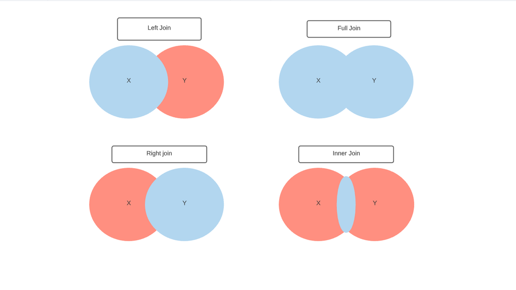

Generar conjuntos de datos para hacer la aplicación:

```r
data_1 = tibble(Casa=c(101,201,201,301),
                Visita=c(2,1,2,1),
                Sexo=c("Mujer","Mujer","Hombre","Hombre"))
data_2 = tibble(Casa=c(101,101,201,201),
                Visita=c(1,2,1,2),
                Edad=c(23,35,7,24),
                Ingresos=c(500000,1000000,NA,2000000))
```

#### **Ejemplo: left_join()**

```r
df <- left_join(x=data_1,y=data_2,by=c("Casa","Visita"))
```

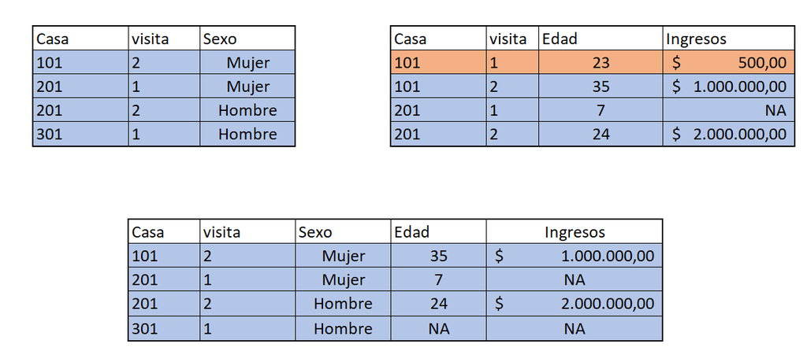

#### **Ejemplo: right_join()**

```r
df <- right_join(x=data_1,y=data_2,by=c("Casa","Visita"))
```

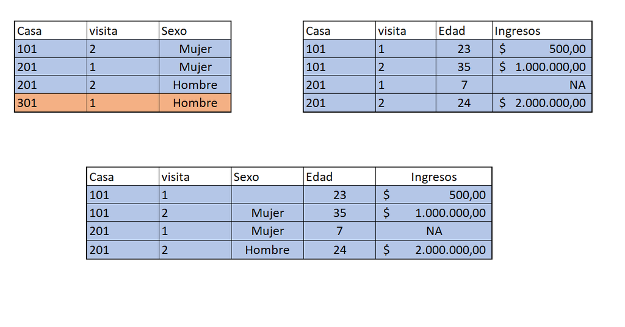

#### **Ejemplo: inner_join()**

```r
df <- inner_join(x=data_1,y=data_2,by=c("Casa","Visita"))
```

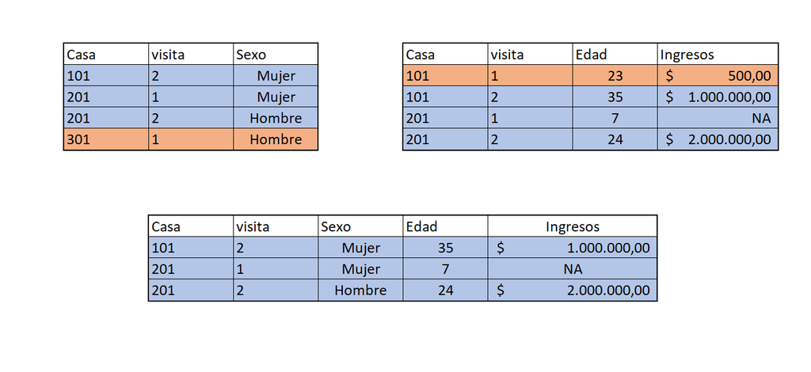

#### **Ejemplo: full_join()**

```r
df <- full_join(x=data_1,y=data_2,by=c("Casa","Visita"))
```

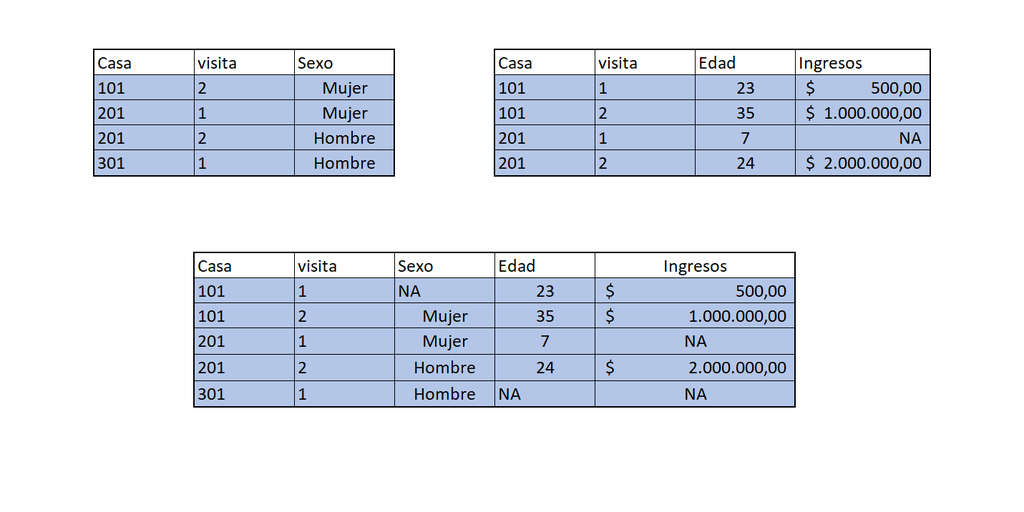

#### **Ejemplo: Join sin identificador único**

```r
df <- full_join(x=data_1,y=data_2,by=c("Hogar"))
```

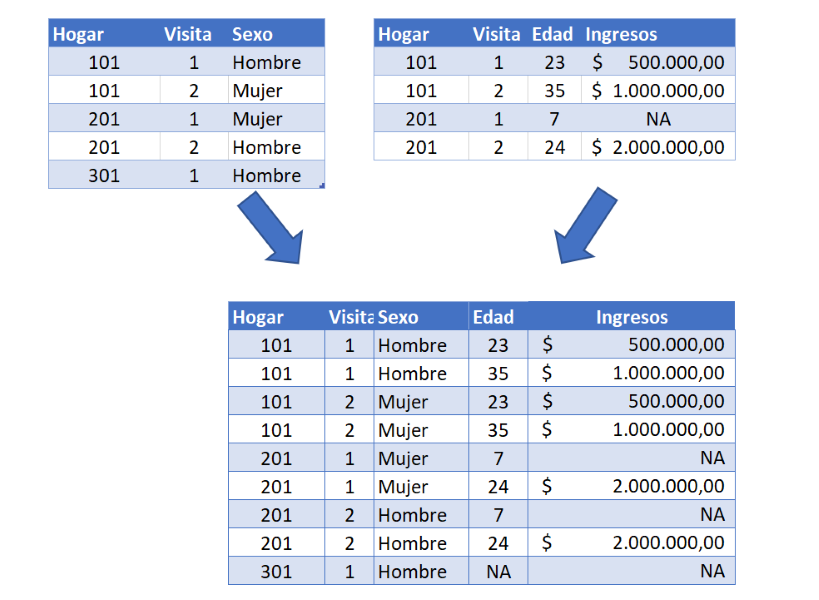

### **4.4 Chequear valores unicos**

Coincidencia en variables:

```r
intersect(colnames(df_1),colnames(df_2))
```

```
## [1] "Hogar"  "Visita"
```

Identificadores únicos:

- `length(unique())`
- `table(duplicated())`
- `nrow(distinct_all())`

## **[5.] Aplicación: GEIH**

El Departamento Administrativo Nacional de Estadística - DANE ha desarrollado encuestas de hogares desde finales de la década del 60 cuando adelantó encuestas de fuerza de trabajo e ingresos y gastos de manera transversal. Durante la década de 1970, se dio inició a la Encuesta Nacional de Hogares (ENH) que fue concebida como un sistema de encuestas, que tuvo como fin producir estadísticas básicas relacionadas con las situaciones: demográfica, social y económica de la población colombiana. A partir del 10 de julio de 2006 se amplió la cobertura de la ECH a 11 ciudades adicionales, a las trece principales ciudades y áreas metropolitanas, al resto de cabeceras y al resto rural.

Puede acceder a los microdatos anonimizados de la GEIH [aquí](https://microdatos.dane.gov.co/index.php/catalog/MICRODATOS/about_collection/23/1) y al diccionario [aquí](https://microdatos.dane.gov.co/catalog/659/data_dictionary).

### **5.3 Componentes del factor de expansión**

- **Factor básico de expansión (F):** Aplicado a los datos muestrales, da a cada elemento de la muestra el peso o representación que le corresponde en el universo investigado.
- **Peso de submuestreo (Ph):** Está dado por segmento y es teóricamente igual a 1 para todos los segmentos en razón de que representan una medida de tamaño.
- **Ajuste de cobertura por no respuesta (Rh):** Cuando las tasas de no respuesta varían en los subgrupos de la población de diferentes características, el ajuste normal es asignar a los hogares y a las personas no encuestadas el promedio de las características de los encuestados en el mismo segmento.
- **El factor final de expansión (Wh):** Es el producto de los anteriores y se aplica a cada segmento de la ciudad o área investigada.

### **5.4 Representatividad**

El DANE, utiliza el factor de expasión para estimar en qué medida de la muestra representa la población. La representatividad de la encuesta a evolucionado así:

- **Año 2007:** La representatividad era para cabeceras municipales del territorio nacional.
- **Año 2008:** Se amplió la cobertura para obtener datos de regiones en el área urbana.
- **Año 2011:** Las regiones determinadas son Bogotá, Atlántica, Central, Oriental y Pacífica con representatividad para las cabeceras municipales del territorio nacional.
- **Años 2015 a 2019:** Se amplió la muestra a centros poblados y rural disperso, con el fin de explorar el área rural.

### **5.5 Nivel geográfico**

La cobertura geográfica permite obtener resultados para cabeceras y resto, ciudades y áreas metropolitanas, grandes regiones y total por departamento.

- **Cabecera:** es el perímetro urbano. Correspondiente al lugar en donde se ubica la sede administrativa de un municipio.
- **Resto:** Contempla los núcleos de población de los corregimientos municipales, inspecciones de policía y caseríos.
- **Área:** conformada por conjuntos de edificaciones y estructuras contiguas agrupadas en manzanas, las cuales están delimitadas por calles, carreras o avenidas, principalmente. En esta categoría están incluidas las ciudades capitales y las cabeceras municipales restantes.

### **5.6 Módulos**

#### **5.6.1 Principales:**

- **Vivienda:** Tipo de vivienda y características físicas (material de paredes y pisos).
- **Datos del hogar:** Conexión a servicios públicos, privados - comunales, valor pagado por consumo y calidad de los mismos, conexión y uso de servicio sanitario, obtención de agua para consumo, lugar y energía para preparar alimentos, eliminación de basuras, tipo de tenencia de la vivienda, tenencia de bienes en el hogar.
- **Características generales:** Sexo, edad, parentesco, estado civil.
- **Educación:** alfabetismo, asistencia escolar, máximo nivel educativo alcanzado y último año aprobado o que esté cursando y títulos o diplomas obtenidos.
- **Fuerza de trabajo:** PEA (ocupados y desocupados).
- **Ocupados:** Asalariados, independientes y asalariados e independientes.
- **Desocupados:** Duración de búsqueda de trabajo, historial laboral, ingresos y seguridad social.
- **Inactivos:** trayectoria laboral, ingresos y seguridad social.

#### **5.6.2 Complementarias:**

- **Registro de personas:** Identificación del residente habitual.
- **Seguridad social en salud:** Cobertura del Sistema General de Seguridad Social en Salud -SGSSS- por regímenes, persona que paga afiliación y cobertura.
- **Otras actividades:** Actividades no remuneradas y ayudas.
- **Otros Ingresos:** Otros ingresos diferentes a los ingresos laborales.
- **Fecundidad:** Cantidades de hijos nacidos vivos y la influencia de la paternidad o maternidad en el mercado laboral.
- **Migración:** Dinámicas migratorias a nivel nacional de la población objetivo.
- **Trabajo Infantil:** Actividades y razones del trabajo infantil.
- **Formación para el trabajo:** Dinámicas de formación para el trabajo, sus características y participación en procesos de certificación de competencias a nivel nacional de la población objetivo.

### **5.7 Llaves**

La llave permite unir los diferentes módulos para poder hacer procesamientos caracterizados. Las varibles que la componen son las siguientes:

- **Directorio:** permite dentificar la vivienda.
- **Secuencia_p:** identifica el hogar.
- **Orden:** hace referencia a las personas.

## **[6.] Unir un conjunto de datos**

```r
## instalar/llamar pacman
require(pacman)

## usar la función p_load de pacman para instalar/llamar las librerías de la clase
p_load(tidyverse, ## manipular/limpiar conjuntos de datos.
       rio, ## para leer/escribir archivos desde diferentes formatos.
       skimr, ## skim: describir un conjunto de datos
       janitor) ##  tabyl: frecuencias relativas
```

```r
cg <- import("input/Enero - Cabecera - Caracteristicas generales (Personas).csv") %>% clean_names()

ocu <- import("input/Enero - Cabecera - Ocupados.csv") %>% clean_names()

geih <- left_join(x = cg, y = ocu, by = c("directorio","secuencia_p","orden"))
```

## **[7.] Descriptivas de un conjunto de datos**

### **7.1 Generales**

**summary** ofrece una descripción general (quartil, media, mediana) de todas las columnas presentes.

```r
## descriptivas del ingreso laboral
summary(geih$inglabo)
```

```
##     Min.  1st Qu.   Median     Mean  3rd Qu.     Max.     NA's
##        0   500000   800000  1114583  1200000 68280000    33285
```

```r
## descriptivas del ingreso laboral y la edad
geih %>% select(inglabo,p6040) %>% summary()
```

```
##     inglabo             p6040
##  Min.   :       0   Min.   :  0.00
##  1st Qu.:  500000   1st Qu.: 16.00
##  Median :  800000   Median : 31.00
##  Mean   : 1114583   Mean   : 34.01
##  3rd Qu.: 1200000   3rd Qu.: 51.00
##  Max.   :68280000   Max.   :110.00
##  NA's   :33285
```

```r
## descriptivas del ingreso laboral y la edad
geih %>% select(clase.x) %>% summary()
```

```
##     clase.x
##  Min.   :1
##  1st Qu.:1
##  Median :1
##  Mean   :1
##  3rd Qu.:1
##  Max.   :1
```

**skimr** ofrece una descripción más detallada de todas las columnas presentes.

```r
geih %>% dplyr::select(p6040,inglabo) %>% skim() ### Computar descriptivas de edad e ingresos laborales.
```

Data summary

| Name | Piped data |
| --- | --- |
| Number of rows | 56644 |
| Number of columns | 2 |
| _______________________ |  |
| Column type frequency: |  |
| numeric | 2 |
| ________________________ |  |
| Group variables | None |

**Variable type: numeric**

| skim_variable | n_missing | complete_rate | mean | sd | p0 | p25 | p50 | p75 | p100 | hist |
| --- | --- | --- | --- | --- | --- | --- | --- | --- | --- | --- |
| p6040 | 0 | 1.00 | 34.01 | 21.64 | 0 | 16 | 31 | 51 | 110 | ▇▇▅▂▁ |
| inglabo | 33285 | 0.41 | 1114582.92 | 1496687.54 | 0 | 500000 | 800000 | 1200000 | 68280000 | ▇▁▁▁▁ |

**select + summarize_all** se usa para obtener las descriptivas deseadas de una o mas variables.,

```r
geih %>%
select(inglabo,p6040) %>%
summarize_all(list('min'=min,'max'= max,'median'= median,'mean'= mean), na.rm = T)
```

```
##   inglabo_min p6040_min inglabo_max p6040_max inglabo_median p6040_median
## 1           0         0    68280000       110         800000           31
##   inglabo_mean p6040_mean
## 1      1114583   34.00523
```

### **7.2 Agrupadas**

**group_by()** toma un tibble/data.frame y lo convierte en un tibble agrupado, donde las operaciones son realizadas por grupo.

```r
## ingreso laboral promedio por sexo
geih %>%
group_by(p6020) %>%
summarise(promedio_inglabo = mean(inglabo, na.rm = T))
```

```
## # A tibble: 2 × 2
##   p6020 promedio_inglabo
##   <int>            <dbl>
## 1     1         1203633.
## 2     2         1007543.
```

```r
## ingreso laboral promedio por sexo y tipo de contrato
geih %>%
group_by(p6020,p6450) %>%
summarise(promedio_inglabo = mean(inglabo, na.rm = T))
```

```
## # A tibble: 8 × 3
## # Groups:   p6020 [2]
##   p6020 p6450 promedio_inglabo
##   <int> <int>            <dbl>
## 1     1     1          769552.
## 2     1     2         1678593.
## 3     1     9          493747.
## 4     1    NA          974461.
## 5     2     1          643222.
## 6     2     2         1582584.
## 7     2     9             NaN
## 8     2    NA          603429.
```

```r
## ingreso laboral promedio/mediano y años promedio en fondo de pension por sexo
geih %>%
group_by(p6020) %>%
summarise(promedio_inglabo = mean(inglabo, na.rm = T),
          mediana_inglabo = median(inglabo, na.rm = T),
          promedio_p6960 = mean(p6960, na.rm = T))
```

```
## # A tibble: 2 × 4
##   p6020 promedio_inglabo mediana_inglabo promedio_p6960
##   <int>            <dbl>           <dbl>          <dbl>
## 1     1         1203633.          828116           13.3
## 2     2         1007543.          781242           11.4
```

```r
## ingreso laboral promedio/mediano y años promedio en fondo de pension por sexo y tipo contrato
geih %>%
group_by(p6020,p6450) %>%
summarise(promedio_inglabo = mean(inglabo, na.rm = T),
          mediana_inglabo = median(inglabo, na.rm = T),
          promedio_p6960 = mean(p6960, na.rm = T))
```

```
## # A tibble: 8 × 5
## # Groups:   p6020 [2]
##   p6020 p6450 promedio_inglabo mediana_inglabo promedio_p6960
##   <int> <int>            <dbl>           <dbl>          <dbl>
## 1     1     1          769552.          781242          14.0
## 2     1     2         1678593.         1100000          12.9
## 3     1     9          493747.          700000         NaN
## 4     1    NA          974461.          720000          15.5
## 5     2     1          643222.          600000           9.11
## 6     2     2         1582584.         1000000          11.3
## 7     2     9             NaN               NA         NaN
## 8     2    NA          603429.          400000          12.9
```

```r
## guardar resultados en objeto y exportar
descrip <- geih %>%
           group_by(p6020,p6450) %>%
           summarise(promedio_inglabo = mean(inglabo, na.rm = T),
                     mediana_inglabo = median(inglabo, na.rm = T),
                     promedio_p6960 = mean(p6960, na.rm = T))
descrip
```

```
## # A tibble: 8 × 5
## # Groups:   p6020 [2]
##   p6020 p6450 promedio_inglabo mediana_inglabo promedio_p6960
##   <int> <int>            <dbl>           <dbl>          <dbl>
## 1     1     1          769552.          781242          14.0
## 2     1     2         1678593.         1100000          12.9
## 3     1     9          493747.          700000         NaN
## 4     1    NA          974461.          720000          15.5
## 5     2     1          643222.          600000           9.11
## 6     2     2         1582584.         1000000          11.3
## 7     2     9             NaN               NA         NaN
## 8     2    NA          603429.          400000          12.9
```

### **7.3 Pivotear**

La familia de **pivot** aumenta la cantidad de columnas o filas dependiendo de lo que se deseé.

```r
descrip_longer = descrip %>%
                  pivot_longer(cols = ends_with(c("inglabo","6960")),
                               names_to = "variable",
                               values_to = "value")

head(descrip_longer, 8)
```

```
## # A tibble: 8 × 4
## # Groups:   p6020 [1]
##   p6020 p6450 variable             value
##   <int> <int> <chr>                <dbl>
## 1     1     1 promedio_inglabo  769552.
## 2     1     1 mediana_inglabo   781242
## 3     1     1 promedio_p6960        14.0
## 4     1     2 promedio_inglabo 1678593.
## 5     1     2 mediana_inglabo  1100000
## 6     1     2 promedio_p6960        12.9
## 7     1     9 promedio_inglabo  493747.
## 8     1     9 mediana_inglabo   700000
```

```r
# pivot_wider retorna la base de datos a su forma original
descrip_wider = descrip_longer %>%
                  pivot_wider(names_from = "variable", values_from = "value")

descrip_wider
```

```
## # A tibble: 8 × 5
## # Groups:   p6020 [2]
##   p6020 p6450 promedio_inglabo mediana_inglabo promedio_p6960
##   <int> <int>            <dbl>           <dbl>          <dbl>
## 1     1     1          769552.          781242          14.0
## 2     1     2         1678593.         1100000          12.9
## 3     1     9          493747.          700000         NaN
## 4     1    NA          974461.          720000          15.5
## 5     2     1          643222.          600000           9.11
## 6     2     2         1582584.         1000000          11.3
## 7     2     9             NaN               NA         NaN
## 8     2    NA          603429.          400000          12.9
```

```r
export(descrip,"output/descriptivas_ingreso.xlsx")
```

## [8.] **Para seguir leyendo**

- Wickham, H., Çetinkaya-Rundel, M., & Grolemund, G. (2023). R for data science: Import, tidy, transform, visualize, and model data (2nd ed.). O’Reilly Media. [Ver aquí](https://r4ds.hadley.nz/data-tidy.html)

  -Cap. 3: Data transformation

  -Cap. 5: Data tidyng

  -Cap. 19: Joins
- Grant McDermott. EC 607: Lectures. Consultado en Febrero 24, 2025, en [GitHub](https://github.com/uo-ec607/lectures).

  -Data wrangling & tidying: Tidyverse [Ver aquí](https://raw.githack.com/uo-ec607/lectures/master/05-tidyverse/05-tidyverse.html)